# Host_Genotype_population_structure

Jacob Agerbo Rasmussen

11/11/2021

The first thing we assess in the covariance between individuals, using PCA. Covariance matrix has been recovered with genotype likelihoods, using ANGSD (http://www.popgen.dk/angsd/index.php/PCA). To minimise inflation, we used minimmal maf of 0.05. We only kept sites present in 90% of individuals (70.2 individuals).

See code; angsd -bam /home/projects/ku-cbd/data/jacras/3-NWS/08_Host_Genotype/sample_list.txt -nThreads 40 -minMapQ 30 -minQ 20 -doGlf 2 -GL 2 -out all -doMajorMinor 1 -doMaf 1 -SNP_pval 2e-6 -doIBS 1 -doCounts 1 -doCov 1 -makeMatrix 1 -minMaf 0.05 -minInd 70.2

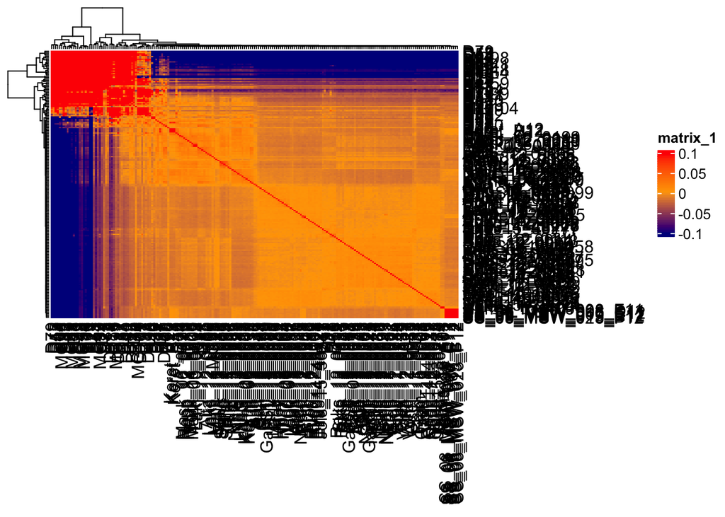

```
## number of clusters estimated by optimum average silhouette width: 2
```

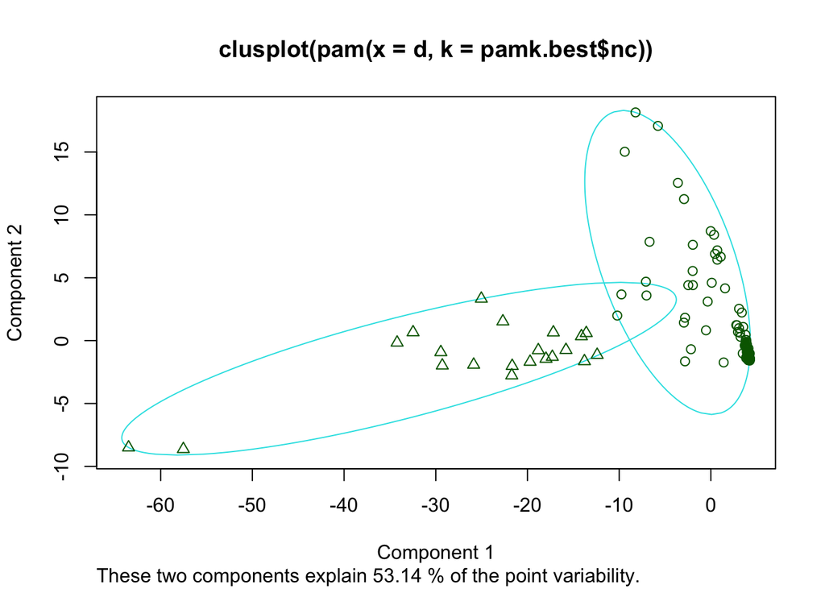

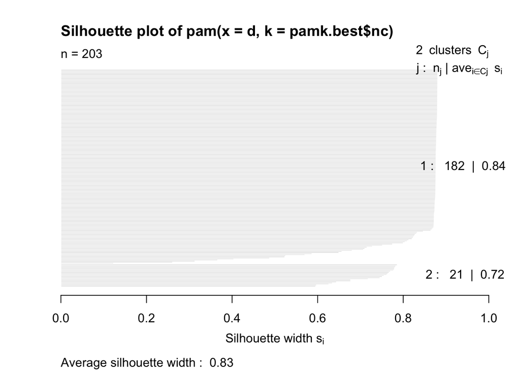

```
## silhouette-optimal number of clusters: 2
```

Okay, so a large chunk of our genotypes seems a bit off and might wash out variance from the Norwegian population structure, since we only cluster between data from our study and bertolotti et al. data.

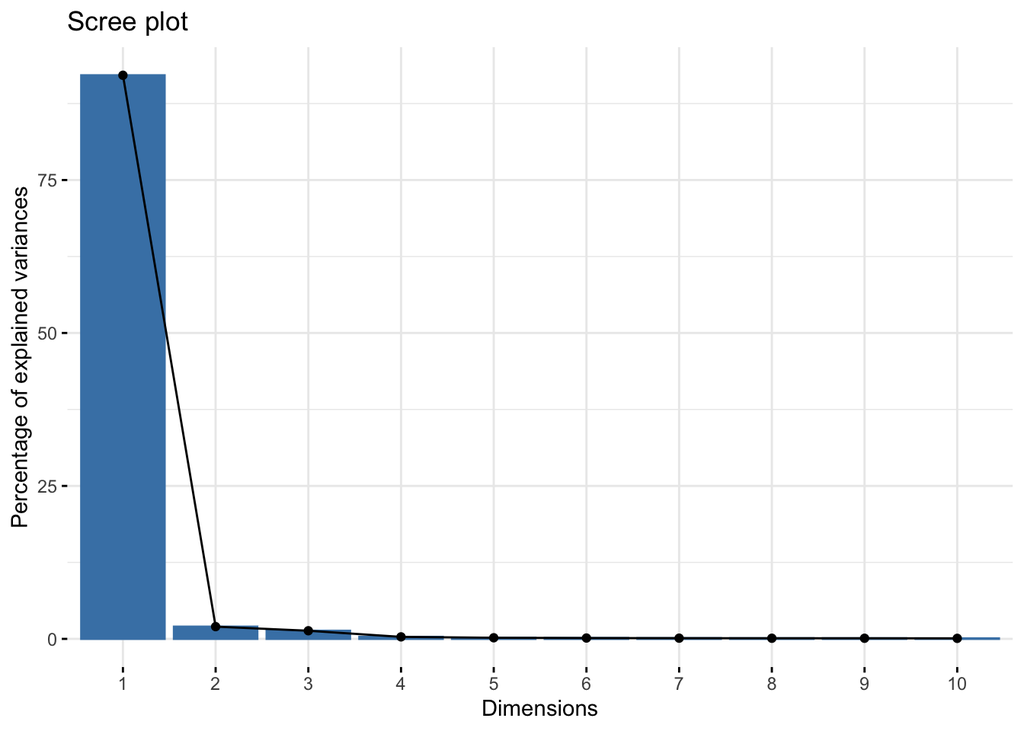

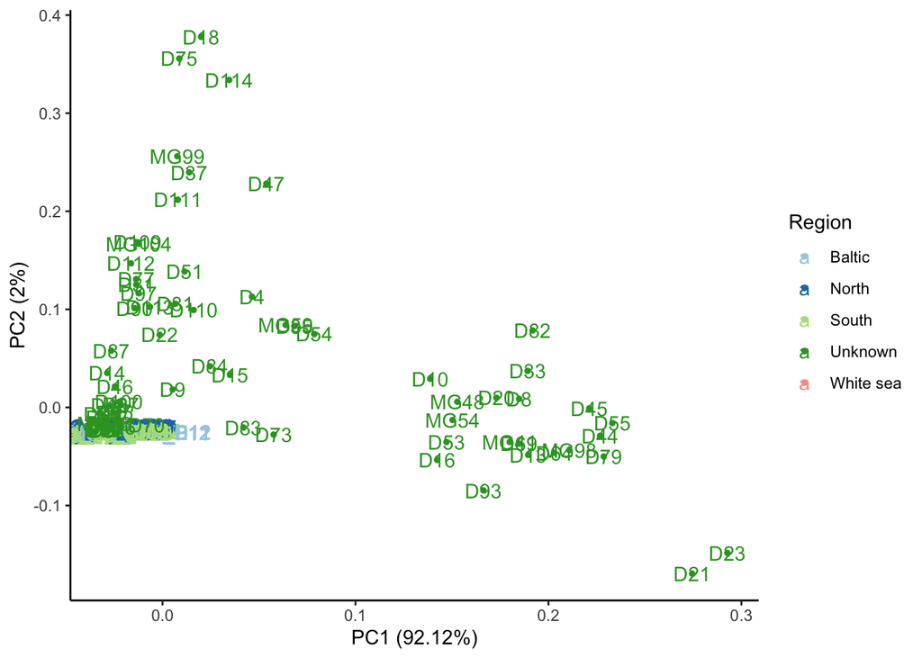

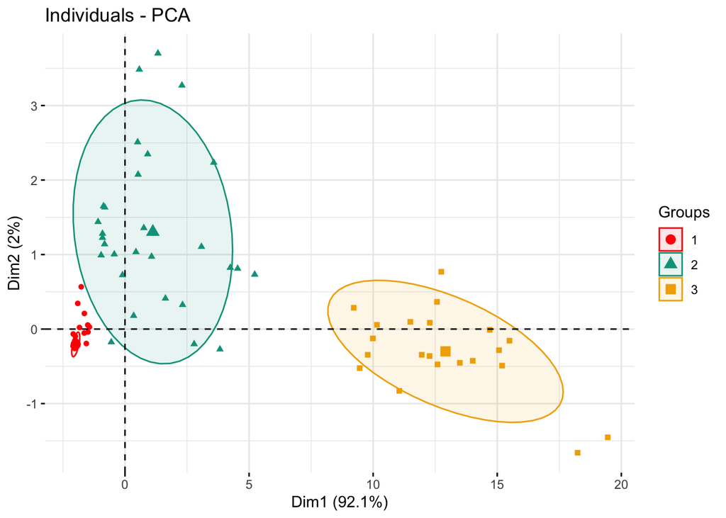

```r
dendro_data_k <- function(hc, k) {

  hcdata    <-  ggdendro::dendro_data(hc, type = "rectangle")
  seg       <-  hcdata$segments
  labclust  <-  cutree(hc, k)[hc$order]
  segclust  <-  rep(0L, nrow(seg))
  heights   <-  sort(hc$height, decreasing = TRUE)
  height    <-  mean(c(heights[k], heights[k - 1L]), na.rm = TRUE)

  for (i in 1:k) {
    xi      <-  hcdata$labels$x[labclust == i]
    idx1    <-  seg$x    >= min(xi) & seg$x    <= max(xi)
    idx2    <-  seg$xend >= min(xi) & seg$xend <= max(xi)
    idx3    <-  seg$yend < height
    idx     <-  idx1 & idx2 & idx3
    segclust[idx] <- i
  }

  idx                    <-  which(segclust == 0L)
  segclust[idx]          <-  segclust[idx + 1L]
  hcdata$segments$clust  <-  segclust
  hcdata$segments$line   <-  as.integer(segclust < 1L)
  hcdata$labels$clust    <-  labclust

  hcdata
}


set_labels_params <- function(nbLabels,
                              direction = c("tb", "bt", "lr", "rl"),
                              fan       = FALSE) {
  if (fan) {
    angle       <-  360 / nbLabels * 1:nbLabels + 90
    idx         <-  angle >= 90 & angle <= 270
    angle[idx]  <-  angle[idx] + 180
    hjust       <-  rep(0, nbLabels)
    hjust[idx]  <-  1
  } else {
    angle       <-  rep(0, nbLabels)
    hjust       <-  0
    if (direction %in% c("tb", "bt")) { angle <- angle + 45 }
    if (direction %in% c("tb", "rl")) { hjust <- 1 }
  }
  list(angle = angle, hjust = hjust, vjust = 0.5)
}
plot_ggdendro <- function(hcdata,
                          direction   = c("lr", "rl", "tb", "bt"),
                          fan         = FALSE,
                          scale.color = NULL,
                          branch.size = 1,
                          label.size  = 3,
                          nudge.label = 0.01,
                          expand.y    = 0.1) {

  direction <- match.arg(direction) # if fan = FALSE
  ybreaks   <- pretty(segment(hcdata)$y, n = 5)
  ymax      <- max(segment(hcdata)$y)

  ## branches
  p <- ggplot() +
    geom_segment(data         =  segment(hcdata),
                 aes(x        =  x,
                     y        =  y,
                     xend     =  xend,
                     yend     =  yend,
                     linetype =  factor(line),
                     colour   =  factor(clust)),
                 lineend      =  "round",
                 show.legend  =  FALSE,
                 size         =  branch.size)

  ## orientation
  if (fan) {
    p <- p +
      coord_polar(direction = -1) +
      scale_x_continuous(breaks = NULL,
                         limits = c(0, nrow(label(hcdata)))) +
      scale_y_reverse(breaks = ybreaks)
  } else {
    p <- p + scale_x_continuous(breaks = NULL)
    if (direction %in% c("rl", "lr")) {
      p <- p + coord_flip()
    }
    if (direction %in% c("bt", "lr")) {
      p <- p + scale_y_reverse(breaks = ybreaks)
    } else {
      p <- p + scale_y_continuous(breaks = ybreaks)
      nudge.label <- -(nudge.label)
    }
  }

  # labels
  labelParams <- set_labels_params(nrow(hcdata$labels), direction, fan)
  hcdata$labels$angle <- labelParams$angle

  p <- p +
    geom_text(data        =  label(hcdata),
              aes(x       =  x,
                  y       =  y,
                  label   =  label,
                  colour  =  factor(clust),
                  angle   =  angle),
              vjust       =  labelParams$vjust,
              hjust       =  labelParams$hjust,
              nudge_y     =  ymax * nudge.label,
              size        =  label.size,
              show.legend =  FALSE)

  # colors and limits
  if (!is.null(scale.color)) {
    p <- p + scale_color_manual(values = scale.color)
  }

  ylim <- -round(ymax * expand.y, 1)
  p    <- p + expand_limits(y = ylim)

  p
}
```

```r
NWSHC <- hclust(dist(d,method = "maximum"),method = "ward.D2")
hcdata <- dendro_data_k(NWSHC, 5)
cols <- get_palette("grey", 5)
cols <- c("black",cols)
p <- plot_ggdendro(hcdata,
                   fan         = FALSE,
                   scale.color = cols,
                   label.size  = 4,
                   nudge.label = 0.15,
                   expand.y    = 0.08)
p_all <- p + theme_void()

Clusters_for_PAN <- cbind(hcdata$labels,md[match(hcdata$labels$label,rownames(md)),])
Clusters_for_PAN <- Clusters_for_PAN[Clusters_for_PAN$Data =="Rasmussen",]
Clusters_for_PAN <- Clusters_for_PAN[,c(3,4,6)]

#write_csv(Clusters_for_PAN, file = "Host_Clusters.csv")

### Subset only cluster will data of known origin, since two clusters are outlying
names.sub <- hcdata$labels$label[hcdata$labels$clust==1]
d.sub <- d[names.sub,names.sub]

NWSHC.sub <- hclust(dist(d.sub),method = "ward.D2")
hcdata.sub <- dendro_data_k(NWSHC.sub, 3)
cols <- get_palette("aaas", 5)
p <- plot_ggdendro(hcdata.sub,
                   fan         = FALSE,
                   scale.color = cols,
                   label.size  = 4,
                   nudge.label = 0.15,
                   expand.y    = 0.08)
p <- p + theme_void()
p_sub = p + geom_point(data     = md,
               aes(x    = match(rownames(md), hcdata.sub$labels$label),
                   y    = -0.2,
                   fill = as.factor(Region)),
               size     = 3,
               shape    = 21,
               show.legend = TRUE) +
  scale_fill_brewer(palette = "Dark2")
```

Okay, so the recovered population structure of Cluster 1 (the norwegian population), seems valid and comparable with Bertolotti et al and Wennevik et al. https://www.nature.com/articles/s41467-020-18972-x/figures/1 https://onlinelibrary.wiley.com/doi/full/10.1002/ece3.5258

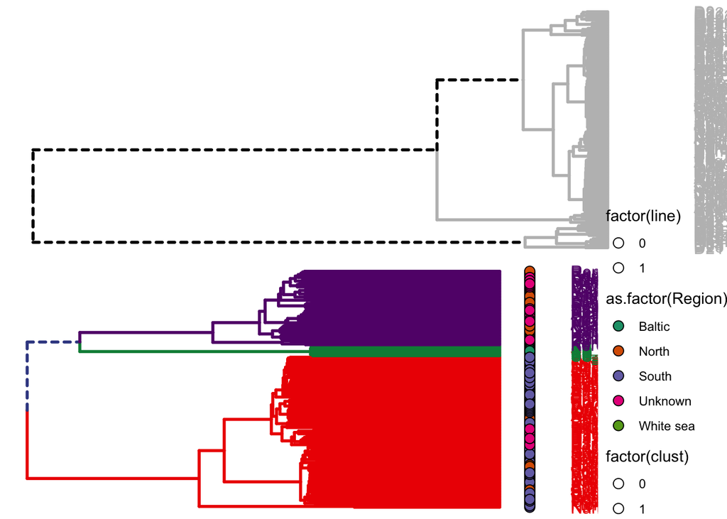

```r
#pdf("NWSHC_max_wardD2_50p_Region.pdf", height = 32, width = 20)
cowplot::plot_grid(p_all,p_sub, ncol = 1)
```

```r
#dev.off()
```

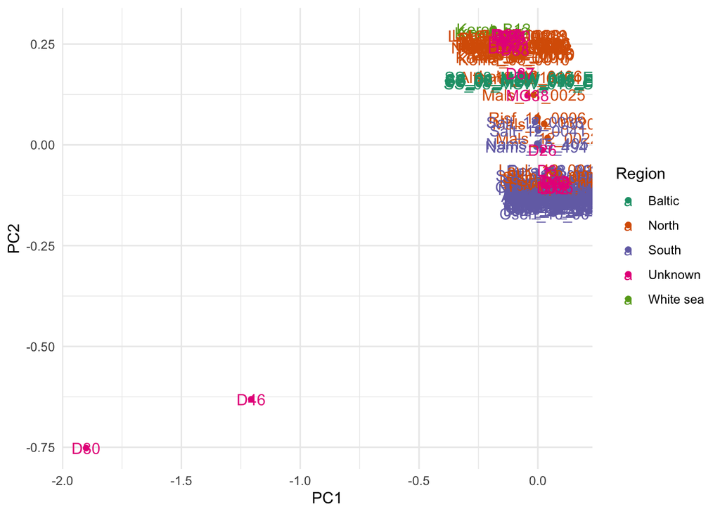

```r
Clusters <- paste("Cluster",NWS_cluster)
cluster_data <- data.frame(names,Clusters)

CL1 <- cluster_data[cluster_data$Clusters == "Cluster 1",]
CL1.df <- d[match(CL1$names, rownames(d)),]
CL1.df <- t(CL1.df)
CL1.df <- CL1.df[match(CL1$names, rownames(CL1.df)),]


CL1.pca <- prcomp(CL1.df)
CL1.data <- CL1.pca[["x"]][,1:2]
CL1.md <- md[match(CL1$names, md$Sample),]
CL1.data <- cbind(CL1.data,CL1,CL1.md)


ggplot(data = CL1.data, aes(x = PC1, y = PC2, color = Region, label = Sample)) +
  geom_point() +
  geom_text() +
  theme_minimal() + scale_fill_brewer(palette = "Dark2") +
  scale_color_brewer(palette = "Dark2")
```

[figure not shown]

```r
# Get clusters for PCA
CL1.HC <- hclust(dist(CL1.df),method = "ward.D2")
#
CL1_subcluster <- cutree(CL1.HC,k=4)
CL1.data$Sub_Cluster <- paste("Cluster",CL1_subcluster)

# Remove outliers
CL1.data <- CL1.data[CL1.data$Sample != "D30",]
CL1.data <- CL1.data[CL1.data$Sample != "D46",]

ggplot(data = CL1.data, aes(x = PC1, y = PC2, color = Sub_Cluster, label = Sample)) +
  geom_point() +
  geom_text() +
  theme_minimal() + scale_fill_brewer(palette = "Dark2") +
  scale_color_brewer(palette = "Dark2")
```

Get data for comparison of High abundant Mycoplasma in salmon

```r
NWS.CL1.data <- CL1.data[CL1.data$Data == "Rasmussen",]
write.csv(NWS.CL1.data,"NWS_CL1_data.csv")
```

```r
pop<-read.table("sample_info.txt",as.is=T)
Clusters <- paste("Cluster",NWS_cluster)
PC_data <- PCs[match(pop$V1, PCs$Sample),]
cluster_data <- data.frame(names,Clusters)
cluster_data <- cluster_data[match(pop$V1, cluster_data$names),]
new_pop_data <- data.frame("ID" = cluster_data$names, "PC_Cluster" = cluster_data$Clusters, "PC1" = PC_data$PC1, "PC2" = PC_data$PC2 )
write_csv(new_pop_data, file = "Host_Clusters.csv")
```

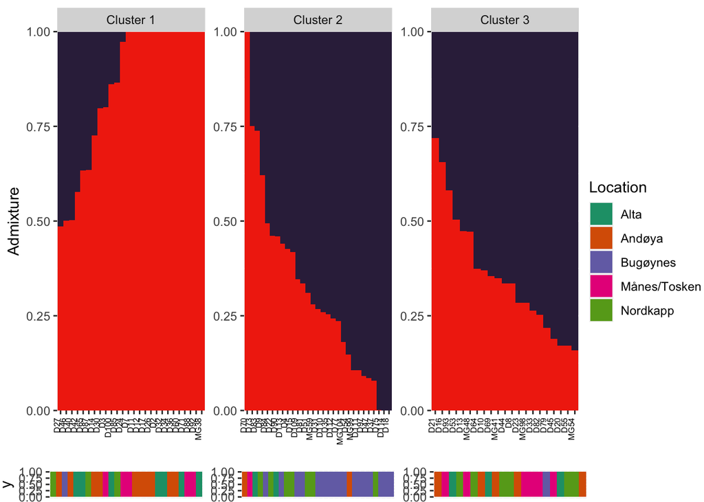

```r
pop[3] <- new_pop_data$PC_Cluster
pop[4] <- new_pop_data$PC1
q<-read.table("Admix/NWS.K2.rep1.qopt")
rownames(q) <- pop[,1]
# order according to population and plot the NGSadmix reults
ord<-orderInds(pop = as.vector(pop[,3]), q = q)

#ord <- as.numeric(rownames(pop[order(pop[,4]),])) # if sorting by PC values instead of pam clusters

df <- t(q)[,ord]



q_melt <- melt(df)
PCA.cluster <- pop[ord,3]
q_melt$Cluster <- rep(PCA.cluster,each=2)
ADMIX_plot <- ggplot(q_melt, aes(x=Var2, y=value, fill = Var1)) + geom_bar(stat= 'identity', width =1) +
  scale_fill_manual(values = wes_palette("Rushmore1")[4:5]) +
  theme(axis.text.x = element_text(angle = 90, hjust = 1, vjust = -0.09, size = 6, color = 'black')) +
  scale_y_continuous(expand = c(0,0))+ theme(legend.position = "none") +
  facet_wrap(~Cluster, scales = "free", nrow = 1) +
  xlab("") + ylab("Admixture")

sample_order <- unique(q_melt$Var2)


pop$V1 <- factor(pop$V1, levels=sample_order)
colnames(pop) <- c("Samples", "Location", "Cluster", "PC1")

Loc_legend <- ggplot(pop, aes(x=Samples, y=1, fill = Location)) +
  geom_bar(stat= 'identity', width =1) +
  scale_fill_brewer(palette = "Dark2") +
  facet_wrap(~Cluster, scales = "free", nrow = 1) +
  xlab("") +
  theme(legend.position = "none") + theme(strip.text.x = element_blank() ,
  strip.background = element_blank(),
  plot.margin = unit( c(0,0,0,0), units = "lines")) +
  theme(axis.title.x=element_blank(),
        axis.text.x=element_blank(),
        axis.ticks.x=element_blank())

Legend <- ggplot(pop, aes(x=Samples, y=1, fill = Location)) +
  geom_bar(stat= 'identity', width =1) +
  scale_fill_brewer(palette = "Dark2") +
  facet_wrap(~Cluster, scales = "free", nrow = 1) +
  xlab("")
Legend <- cowplot::get_legend(Legend)

ADMIX_plot <- plot_grid(ADMIX_plot,Loc_legend, ncol = 1, rel_heights = c(15,1))
ADMIX_plot <- plot_grid(ADMIX_plot, Legend, nrow = 1, rel_widths =  c(5,1))
ADMIX_plot
```

We used EValAdmix from ANGSD developers to evaluate the results of an admixture analysis. The output is a pairwise correlation of residuals matrix between individuals. The correlation will be close to 0 in case of a good fit of the data to the admixture model. When individuals do not fit the model, individuals with similar demographic histories (i.e. usually individuals from the same population) will be positively correlated; and individuals with different histories but that are modelled as sharing one or more ancestral populations as admixture sources will have a negative correlation. Positive correlation between a pair of individuals might also be due to relatedness.

For more information, please have a look at: http://www.popgen.dk/software/index.php/EvalAdmix